# CE310 - Modelos de Regressão Linear

## Lista de exercícios

#### 1. Defina o modelo de regressão linear simples. Especifique cada um de seus componentes e as suposições assumidas para os erros.

- O modelo de regressão linear simples é definido pelo ajuste de uma reta que estabelece a relação entre uma variável resposta (Y) e uma variável explicativa (X).
- O modelo possui a seguinte forma: **y = B0 + B1X + e**, onde **y** é a variável resposta, **B0** é o intercepto da reta, **B1** é o coeficiente de inclinação da reta, que pode ser interpretado como o efeito linear de X em Y, **X** é a variável explicativa e o **e** é o erro aleatório associado à reta ajustada dos valores reais de Y.
- Algumas suposições importantes para o erro: Deve seguir uma distribuição normal com média centrada em 0 e, independência entre os erros, ou seja, não pode existir correlação entre um erro e outro, e a homocedasticidade dos erros, ou seja, a variância deve ser constante em todos os intervalos de X.

#### 2. Qual o princípio da estimação por mínimos quadrados? Quais as principais propriedades dos estimadores de mínimos quadrados dos parâmetros de um modelo de regressão linear?

- Estimação por mínimos quadrados segue o princípio de estimar uma reta cujo a soma das distâncias entre a reta e os valores reais seja mínima.

#### 3. Qual o princípio da estimação por máxima verossimilhança? Qual a relação dos estimadores de mínimos quadrados e de máxima verossimilhança dos parâmetros do modelo de regressão linear se assumirmos que os erros são normalmente distribuídos?

#### 4. Considere o modelo de regressão linear simples com β0 = 10, β1 = 5 e σ = 4. Assuma distribuição normal para os erros.

- 1. Apresente gráficos da distribuição de y condicional a (i) x = 3; (ii) x = 5 e (iii) x = 10;

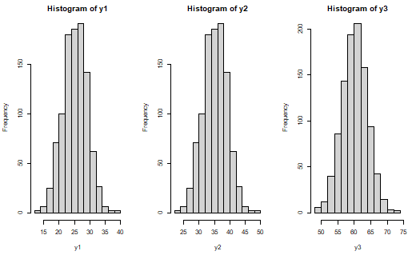

- 2. Descreva o significado de β0 e β1. Suponha que x = 0 pertença ao escopo do modelo;
  - β0 é o intercepto da reta. Em termos prático, ele representa o valor médio de Y dado que X = 0
  - β1 é o coeficiente angular da reta. Podemos interpretar como o efeito linear de X em Y, ou seja, para cada unidade de X tem impacto β1 em Y.
- 3. Calcule P(20 < y < 30) para: (i) x = 3; x = 5.

```r
#x = 3
mean(y1<30 & y1>20)
#x = 5
mean(y2<30 & y2>20)
```

[output not shown]